# The Itô Integral: Construction, Isometry, and Localization

## 1. Simple adapted processes

A process $f:[0,T]\times\Omega\rightarrow\mathbb R$ is measurable when it is $\mathcal B([0,T])\times\mathcal F_T$-measurable, and it is adapted when $f(t,\cdot)$ is $\mathcal F_t$-measurable for every $t\in[0,T]$. The space $H^2$ consists of measurable adapted processes satisfying

$$ \|f\|_{L^2([0,T]\times\Omega)}^2:=\mathbb E\!\left[\int_0^T |f(t)|^2\,dt\right]<\infty. $$

Its simple-process subclass $H_0^2$ contains functions of the form

$$ f(t,\omega)=\sum_{i=0}^{n-1}a_i(\omega)1_{(t_i,t_{i+1}]}(t), \qquad a_i\in L^2(\Omega,\mathcal F_{t_i},P). $$

Because $a_i$ is $\mathcal F_{t_i}$-measurable, it is chosen from the information available at $t_i$ and then held over $(t_i,t_{i+1}]$. The following Brownian increment is still unknown when the coefficient is chosen. The Itô integral of the simple process is

$$ I(f)=\sum_{i=0}^{n-1}a_i\left(B_{t_{i+1}}-B_{t_i}\right). $$

In the example below, $a_i=1+0.55B_{t_i}$. The number of intervals can be changed through `n_intervals` in the code cell.

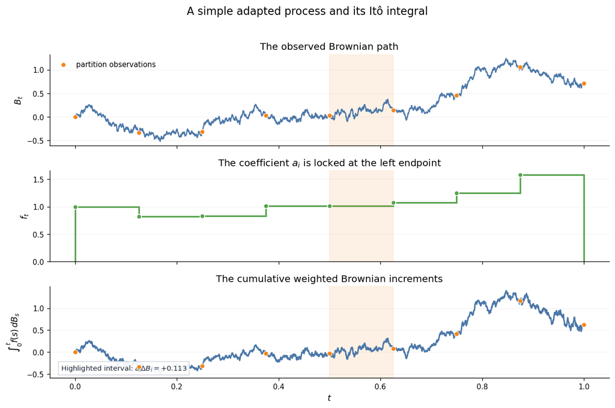

**Figure 1.** A Brownian path, a simple adapted integrand, and the resulting cumulative Itô integral.

Interpretation. Each orange point in the upper panel is information already observed at a partition time $t_i$. That value determines $a_i=1+0.55B_{t_i}$ in the middle panel, and the coefficient then stays fixed while the next Brownian increment remains unknown. Over the highlighted interval, the integral changes by exactly $a_i\Delta B_i$. Repeating this rule across the partition produces the lower path, whose terminal value is the sum in the definition of $I(f)$.

## 2. Itô isometry and the $L^2$ extension

For every $f\in H_0^2$, Lemma 4.2 gives

$$ \|I(f)\|_{L^2(\Omega)}=\|f\|_{L^2([0,T]\times\Omega)}, $$

or, equivalently,

$$ \mathbb E\!\left[I(f)^2\right] =\mathbb E\!\left[\int_0^T f(t)^2\,dt\right]. $$

Figure 2 represents each integrand $f$ by the coordinate pair

$$ x_f=\mathbb E\!\left[\int_0^T f(t)^2\,dt\right], \qquad y_f=\mathbb E\!\left[I(f)^2\right]. $$

The Itô isometry states that the exact pair satisfies $y_f=x_f$. Figure 2 compares Monte Carlo estimates of $y_f$ with this equality line. Because $H_0^2$ is dense in $H^2$, the isometry sends an $L^2$-Cauchy sequence of simple integrands to an $L^2(\Omega)$-Cauchy sequence of integrals. Its limit defines $I(f)$ for every $f\in H^2$ and is independent of the chosen approximation.

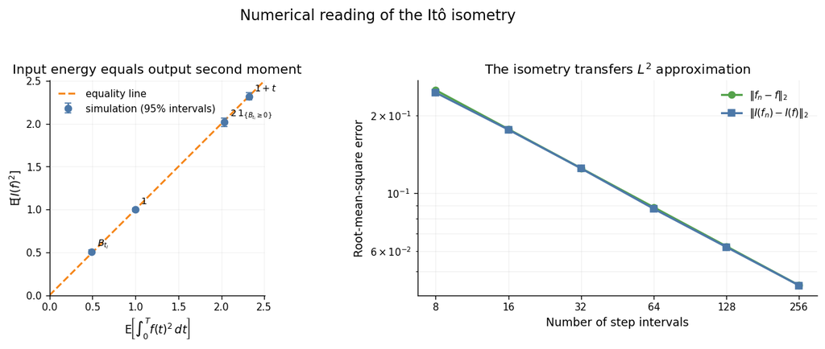

**Figure 2.** Second-moment checks for the Itô isometry and matched $L^2$ errors under simple-process approximation.

Interpretation. The four markers correspond to two deterministic integrands, $1$ and $1+t$, and two state-dependent integrands, $2\,1_{\{B_{t_i}\geq0\}}$ and $B_{t_i}$. The horizontal coordinate is the estimated input energy, while the vertical coordinate estimates the output second moment. The markers lie close to $y=x$; their departures from the line and the vertical intervals reflect Monte Carlo uncertainty. In the right panel, the analytic integrand error and the simulated integral error decrease on the same scale, as prescribed by the isometry.

## 3. The integral as a continuous martingale

For a fixed $t$, the random variable $I\left(1_{[0,t]}f\right)$ is an element of $L^2(\Omega)$, so its representative may be changed on a null set $A_t$. Choosing representatives separately for every $t\in[0,T]$ does not yet define a coherent process: the index set is uncountable, and $\bigcup_{t\in[0,T]}A_t$ need not be a null set.

Theorem 4.10 resolves this version problem. For $f\in H^2$, it constructs a continuous martingale $(X_t)_{t\in[0,T]}$ such that, for each fixed $t\in[0,T]$,

$$ P\!\left(X_t=I\left(1_{[0,t]}f\right)\right)=1. $$

The equality is asserted at each fixed time; the theorem supplies one continuous process whose coordinates have these $L^2$ representatives. This continuous version is denoted by $X_t=\int_0^t f(s)\,dB_s$. The figure uses the deterministic adapted integrand $f(t)=1+0.75\sin(2\pi t)$ and replaces it by successively finer simple processes.

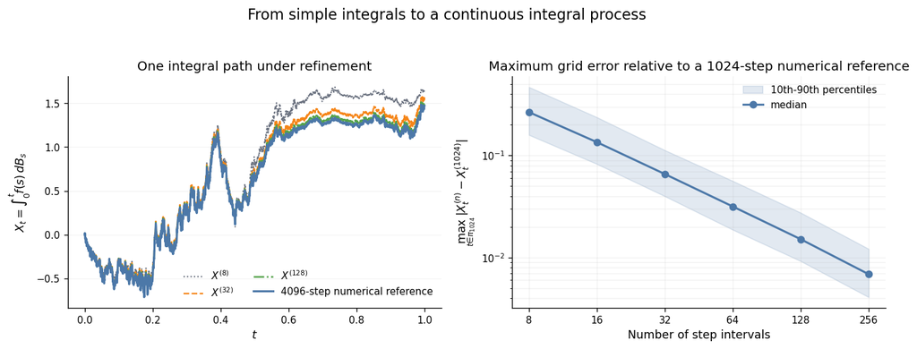

**Figure 3.** Simple-process approximations to an integral path and grid-maximum errors relative to a 1024-step numerical reference.

Interpretation. The curves on the left share the same Brownian increments. With eight intervals, one coefficient is held over a relatively long stretch of time; finer partitions update it more frequently and move toward the blue 4096-step numerical reference. The right panel repeats the comparison over many simulations on the uniform 1024-step grid $\pi_{1024}$. The median grid-maximum error and its central 80% range decrease numerically under refinement. Both fine-grid curves are numerical references, so the plotted errors exclude their remaining discretisation error.

## 4. The canonical integral $\int_0^t B_s\,dB_s$

Example 4.12 establishes

$$ \int_0^t B_s\,dB_s=\frac{B_t^2-t}{2}. $$

On each partition interval, the algebraic identity

$$ 2B_{t_i}\left(B_{t_{i+1}}-B_{t_i}\right) =B_{t_{i+1}}^2-B_{t_i}^2-\left(B_{t_{i+1}}-B_{t_i}\right)^2. $$

For the uniform partition $t_i=iT/n$, the left-point sum up to $t_k$ is

$$ S_{t_k}^{(n)}=\sum_{i=0}^{k-1} B_{t_i}\left(B_{t_{i+1}}-B_{t_i}\right). $$

This is the left-endpoint rule from Section 1: $B_{t_i}$ is $\mathcal F_{t_i}$-measurable before the following increment is observed. Summing the identity above gives $S_{t_k}^{(n)}=\tfrac12 B_{t_k}^2-\tfrac12\sum_{i<k}(B_{t_{i+1}}-B_{t_i})^2$, so the correction is generated by the accumulated squared Brownian increments.

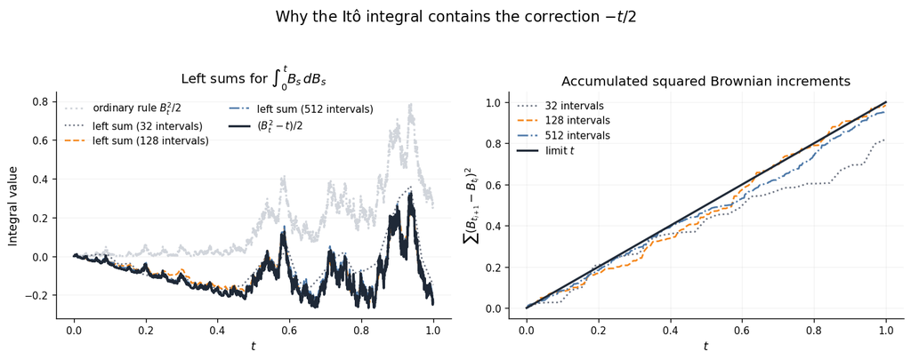

**Figure 4.** Left-point approximations to $\int_0^t B_s\,dB_s$ and the squared-increment term responsible for the correction.

Interpretation. All curves use the same Brownian path on $[0,1]$. Here $n$ is the number of equal partition intervals: $n=32$, $128$, and $512$ correspond to step widths $1/32$, $1/128$, and $1/512$. A larger $n$ updates the left-endpoint value more frequently, so the coloured left sums become finer approximations to the black curve $(B_t^2-t)/2$. The grey dotted ordinary-chain-rule curve lies exactly $t/2$ above the correct integral. For each partition, the left sum equals one half of $B_t^2$ minus one half of the corresponding squared-increment sum. The right panel shows these accumulated squared increments settling toward $t$ as the mesh becomes finer, which explains the correction $-t/2$.

## 5. Stopping and localization

The space $H^2$ requires finite expected energy. The larger class $L_{\mathrm{loc}}^2([0,T])$ consists of adapted processes with finite energy along almost every path:

$$ P\!\left(\int_0^T |f(s)|^2\,ds<\infty\right)=1. $$

Chapter 4 controls such an integrand through the stopping times

$$ \tau_n(f)=\inf\left\{t\geq0:\int_0^t|f(s)|^2\,ds\geq n\ \text{or}\ t\geq T\right\} $$

and integrates the stopped process first. The example uses $f(t)=\exp(B_t^2)$. Brownian paths are continuous and therefore bounded on $[0,1]$, so $\int_0^1\exp(2B_s^2)\,ds<\infty$ almost surely. Hence $f\in L_{\mathrm{loc}}^2([0,1])$. Since $B_s\sim N(0,s)$, its Gaussian density gives $\mathbb E[\exp(2B_s^2)]=(1-4s)^{-1/2}$ for $s<1/4$ and $\infty$ for $s\geq1/4$. Thus $f\notin H^2$ on $[0,1]$.

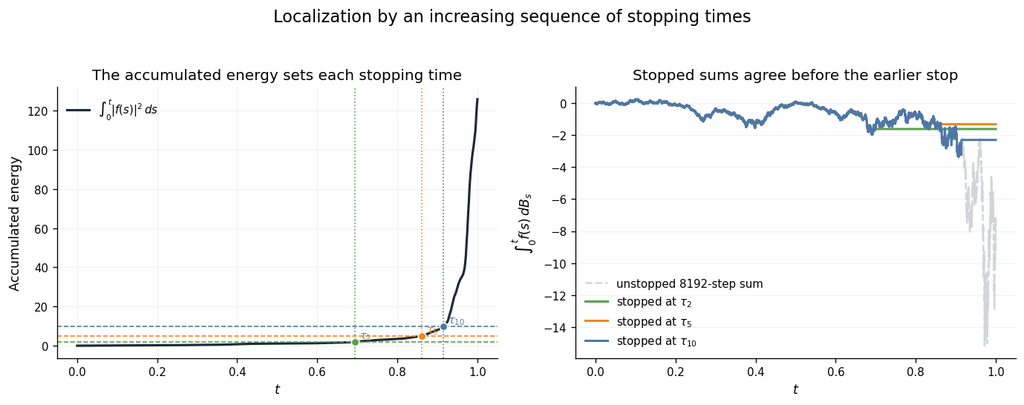

**Figure 5.** Energy-based stopping times and the corresponding 8192-step stopped sums.

Interpretation. The black curve records the accumulated squared energy along one Brownian path. Its first crossing of each horizontal level defines $\tau_2$, $\tau_5$, or $\tau_{10}$. In the right panel, the stopped sums agree up to the earlier stopping time; each becomes flat after reaching its own threshold, while the sums with larger thresholds continue. Proposition 4.19 uses this consistency to join the localized processes into an Itô integral for $f\in L_{\mathrm{loc}}^2([0,T])$.

## 6. Left-point sums for $f(B_t)$

If $f:\mathbb R\rightarrow\mathbb R$ is continuous and $t_i^{(N)}=iT/N$, Theorem 4.22 states that

$$ \sum_{i=1}^{N}f\left(B_{t_{i-1}^{(N)}}\right) \left(B_{t_i^{(N)}}-B_{t_{i-1}^{(N)}}\right) \xrightarrow{P} \int_0^T f(B_s)\,dB_s. $$

The simulation sets $f(x)=x$, for which Example 4.12 supplies the exact terminal benchmark $(B_T^2-T)/2$.

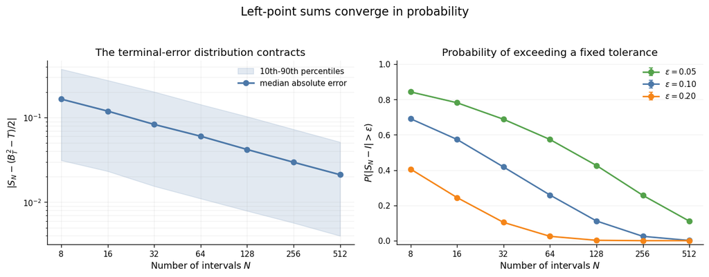

**Figure 6.** Absolute errors and exceedance probabilities for left-point approximations to $\int_0^T B_s\,dB_s$.

Interpretation. The left panel summarizes the terminal error over many Brownian paths. As $N$ increases, both the median and the central 80% range move downward in this simulation. The right panel estimates, for each fixed tolerance $\varepsilon$, how often the error exceeds it. All three estimated probabilities fall over the displayed meshes. Theorem 4.22 supplies convergence in probability; the panels report its finite-sample numerical pattern for $f(x)=x$.